# R Notebook

```r
library(tidyverse)
library(infer)
library(janitor)
```

#1 Learning objectives

```
Understand the concept of a confidence interval.
Understand and be able to perform bootstrap resampling.
Gain experience with the infer package.
Be able to calculate confidence intervals
```

Life is full of uncertainty Confidence intervals are a tool that allow us to describe how confident we are about a measurement (point estimate)

```r
telco <- read_csv("data/telecomms_churn.csv")
```

```
* `` -> ...1
```

```r
telco <- clean_names(telco)
```

We made a sample (200 rows) of a population (the whole dataset) and then calculater a mean of that sample

```r
sample_200 <- telco %>%
  rep_sample_n(size = 200, reps = 1)

summary_sample_200 <- sample_200 %>%
  ungroup() %>%
  summarise(
    mean_monthly_charges = mean(monthly_charges),
    mean_tenure = mean(tenure),
    prop_churn = mean(churn == "Yes")
  )
summary_sample_200
```

| mean_monthly_charges | mean_tenure | prop_churn |
| --- | --- | --- |
| 63.2005 | 32.23 | 0.255 |

In this case we KNOW what the true (population) value for mean(tenure) is: 32.37

```r
summary_popn <- telco %>%
  summarise(
    mean_monthly_charges = mean(monthly_charges),
    mean_tenure = mean(tenure),
    prop_churn = mean(churn == "Yes")
  )
summary_popn
```

| mean_monthly_charges | mean_tenure | prop_churn |
| --- | --- | --- |
| 64.76169 | 32.37115 | 0.2653699 |

The only reason we know this … is because we have the data for the population.

What can we do if we don’t know the Truw value (we usually won’t)

# Confidence Interval

lower bound - upper bound

- a range where we can say with a degree of confidence the truw value exists

Lets us say things like:

From our 200 obser. sample, the point estimate of mean tenure is 32.725 months with a 95% confidence interval of [25, 35] months

The CI formula :

= sample mean +/- sample sd / sqrt(sample size)

What this actually means

For a 95% confidence level, if we took 100 samples , calculating point estimates (mean tenure) and confidence intervals, we would expect 95 of the determined confidence intervals to contain the true value of the population parameter

Ew - to wordy

Key takeawys

CI - range of values around a point estimate where we are confident the pop. value exists

CI are proportional to the standard error

(typically larger sample size = narrower CI)

A larger CI corresponds to a larger set of Values (wider range)

# Bootstrapping (sample magic)

So in practice we often have one (or a few) samples to work with

bootstrapping allows us to use computational power to generate sampling distributions from just one sample

tries to replicate collevting new samples

follows central limit theorm -> over time becomes normally distributed

Bootstrapping samples the sample with replacement

```r
de11 <- c("jonny", "louise", "malcolm", "pui", "ricardo")

sample(de11, replace = TRUE)
```

```
[1] "ricardo" "jonny"   "jonny"   "louise"  "ricardo"
```

Bootstrapping is one of our solutions to the problem of having a limited sample/one sample

# Stating Point

```r
sample_200 <- read_csv("data/telecomms_churn_200_sample.csv") %>%
  clean_names()
```

```r
head(sample_200)
```

| customer_id | gender | senior_citizen | partner | dependents | tenure | phone_service | multiple_lines | internet_service | online_security | online_backup | device_protection | tech_support | streaming_tv | streaming_movies | contract | paperless_billing | payment_method | monthly_charges | total_charges | churn |
| --- | --- | --- | --- | --- | --- | --- | --- | --- | --- | --- | --- | --- | --- | --- | --- | --- | --- | --- | --- | --- |
| 0799-DDIHE | Female | 0 | Yes | Yes | 15 | Yes | No | DSL | No | No | No | No | No | No | Month-to-month | No | Electronic check | 46.30 | 639.45 | No |
| 2587-EKXTS | Male | 0 | No | No | 44 | Yes | Yes | Fiber optic | Yes | Yes | Yes | No | Yes | Yes | Month-to-month | Yes | Electronic check | 111.50 | 4915.15 | No |
| 0708-SJDIS | Female | 0 | No | No | 34 | Yes | Yes | DSL | No | No | No | Yes | Yes | No | Month-to-month | No | Mailed check | 65.00 | 2157.50 | No |
| 0071-NDAFP | Male | 0 | Yes | Yes | 25 | Yes | Yes | No | No internet service | No internet service | No internet service | No internet service | No internet service | No internet service | Two year | No | Credit card (automatic) | 25.50 | 630.60 | No |
| 2885-HIJDH | Male | 0 | Yes | Yes | 69 | Yes | Yes | DSL | Yes | No | Yes | Yes | Yes | Yes | Two year | No | Bank transfer (automatic) | 86.90 | 6194.10 | No |
| 6959-GQEGV | Male | 0 | No | No | 45 | Yes | No | DSL | Yes | No | Yes | No | Yes | Yes | Month-to-month | Yes | Electronic check | 75.95 | 3273.80 | No |

point estimate = mean tenure

```r
bootstrap_resample <- sample_200 %>%
  # 5000
  rep_sample_n(size = 200, reps = 500, replace =  TRUE) %>%
  summarise(
    mean_tenure = mean(tenure)
  )

bootstrap_resample
```

| replicate | mean_tenure |
| --- | --- |
| 1 | 33.065 |
| 2 | 31.560 |
| 3 | 34.405 |
| 4 | 35.440 |
| 5 | 31.805 |
| 6 | 28.270 |
| 7 | 37.310 |
| 8 | 37.750 |
| 9 | 32.785 |
| 10 | 33.700 |

[output cut: 490 more lines]

### Task - 5 mins

```
Plot a histogram of the bootstrapped sampling distribution
Calculate the standard error in mean(tenure) and compare it with the previous value 1.72 months [remember: this is just the sd() of the sampling distribution]
```

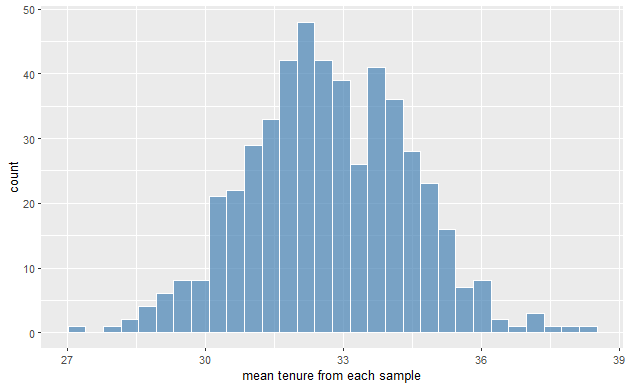

```r
bootstrap_resampleplot <- bootstrap_resample %>%
  ggplot(aes(x = mean_tenure)) +
  geom_histogram(col = "white", fill = "steel blue", alpha = 0.7) +
  labs(x = "mean tenure from each sample")

bootstrap_resampleplot
```

```r
std_errs <- bootstrap_resample %>%
  summarise(
    se_mean_tenure = sd(mean_tenure)
  )
std_errs
```

| se_mean_tenure |
| --- |
| 1.750075 |

This exercise was just to verify that bootstrapping could produce similar results to taking multiple samples

Important notes

- the size of each generated sample is the same as the sample size

se ~ 1/sqrt(sample_size) ci ~ 1/sqrt(sample_size)

Bootstrapping is just computer-based accuracy metric, not creating fictitious data

What would happen if we didn’t sample WITH replacement

mean(tenure) of original sample * 5000

# Confidence Intervalss from the bootstrap distribution

```r
ci_95 <- bootstrap_resample %>%
  summarise(
    mean = mean(mean_tenure),
    # 2.5% data below
    lower_bound = quantile(mean_tenure, probs = 0.025),
    # 97.5% data below
    upper_bound = quantile(mean_tenure, probs = 0.975)
  )

ci_95
```

| mean | lower_bound | upper_bound |
| --- | --- | --- |
| 32.67091 | 29.23975 | 35.98787 |

### Task - 2 mins

```
Try a similar approach to determine the upper and lower bounds of a 99% confidence interval for mean(tenure) based on the bootstrap sampling distribution.
Compare your calculated bounds to those of the 95% CI - is the 99% CI wider or narrower?
```

[Hint - think about how much of the distribution you want to ‘chop off’ at either end of the CI]

```r
ci_99 <- bootstrap_resample %>%
  summarise(
    mean = mean(mean_tenure),
    # 0.5% data below
    lower_bound = quantile(mean_tenure, probs = 0.005),
    # 99.5% data below
    upper_bound = quantile(mean_tenure, probs = 0.995)
  )

ci_99
```

| mean | lower_bound | upper_bound |
| --- | --- | --- |
| 32.67091 | 28.35663 | 37.33272 |

Confidence interval gets wider for a higher degree of confidence level (99%)

# Infer Workflow - Specify!, Generate!, Calculate!

using the infer package, which is more tidyverse-y

1, Derive the bootstrap distribution 2, Get confidence interval 3, Visualize our ci 4, Get our point estimate

## 1, Derive the bootstrap distribution

specify - our variable of interest generate - our sampling distribution calculate - our statistic of interest To re-do what we did above in infer languague:

```r
infer_resample <- sample_200 %>%
  specify(response = tenure) %>%
  generate(reps = 5000, type = "bootstrap") %>%
  calculate(stat =  "mean")

infer_resample
```

```
Response: tenure (numeric)
```

[output not shown]

[output cut: 990 more lines]

## 2, Get confidence interval

Let’s do 95% ci levels again

```r
infer_ci_95 <- infer_resample %>%
  get_ci(level = 0.95, type = "percentile")

infer_ci_95
```

| lower_ci | upper_ci |
| --- | --- |
| 29.135 | 36.065 |

## Visualise the sampling distribution and CI

infer makes this nice and easy with `visualise()` and `shade_confidence_interval()`

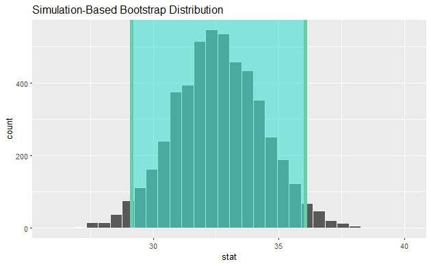

```r
infer_resample %>%
  # similar to ggplot(, + from here on
  visualise(bins = 30) +
  # we calculated endpoints in a step
  shade_ci(endpoints = infer_ci_95)
```

## 4, Get our point estimate

```r
mean_infer <- infer_resample %>%
  summarise(mean = mean(stat))

mean_infer
```

| mean |
| --- |
| 32.59011 |

### Task - 15 mins

Now, it’s your turn.

```
In the data folder you will also find a csv file containing a 300-observation sample. Load it, and use that sample to calculate and visualise a bootstrapped 95% CI for mean(tenure) using the infer workflow.
Also calculate the point estimate of mean(tenure).
Write down your interpretation of your findings.
Is the width of the 95% CI for your 300-observation sample different from that you calculated earlier for a 200-observation sample?
If you have time, rerun your code with 400- and 500-observation samples (you’ll also find csvs for these in the data folder), and keep note of the CIs you obtain. Is there any trend to the width as sample size changes?
```

```r
sample_300 <-  read_csv("data/telecomms_churn_300_sample.csv") %>%
  clean_names()
```

```r
infer_300 <-  sample_300 %>%
  specify(response = tenure) %>%
  generate(reps = 5000, type = "bootstrap") %>%
  calculate(stat = "mean")
```

```r
infer_300_ci_95 <- infer_300 %>%
  get_ci(level = 0.95, type = "percentile")

infer_300_ci_95
```

| lower_ci | upper_ci |
| --- | --- |
| 30.30617 | 35.76692 |

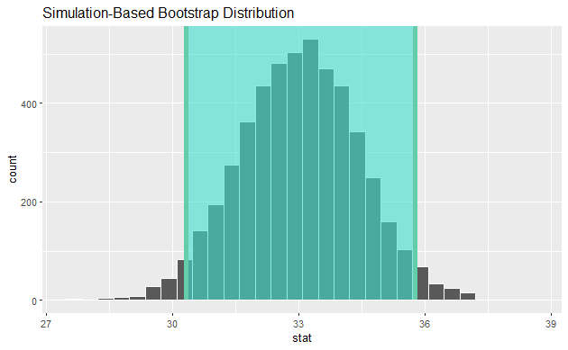

```r
infer_300 %>%
  visualise(bins = 30) +
  shade_confidence_interval(endpoints = infer_300_ci_95)
```

```r
mean_infer_300 <- infer_300 %>%
  summarise(mean = mean(stat))

mean_infer_300
```

| mean |
| --- |
| 33.00978 |

#### 400

```r
sample_400 <-  read_csv("data/telecomms_churn_400_sample.csv") %>%
  clean_names()
```

```r
infer_400 <-  sample_400 %>%
  specify(response = tenure) %>%
  generate(reps = 5000, type = "bootstrap") %>%
  calculate(stat = "mean")
```

```r
infer_400_ci_95 <- infer_400 %>%
  get_ci(level = 0.95, type = "percentile")

infer_400_ci_95
```

| lower_ci | upper_ci |
| --- | --- |
| 29.81994 | 34.6475 |

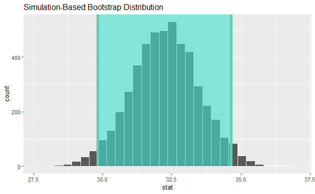

```r
infer_400 %>%
  visualise(bins = 30) +
  shade_confidence_interval(endpoints = infer_400_ci_95)
```

```r
mean_infer_400 <- infer_400 %>%
  summarise(mean = mean(stat))

mean_infer_400
```

| mean |
| --- |
| 32.25493 |

#### 500

```r
sample_500 <-  read_csv("data/telecomms_churn_500_sample.csv") %>%
  clean_names()
```

```r
infer_500 <-  sample_500 %>%
  specify(response = tenure) %>%
  generate(reps = 5000, type = "bootstrap") %>%
  calculate(stat = "mean")
```

```r
infer_500_ci_95 <- infer_500 %>%
  get_ci(level = 0.95, type = "percentile")

infer_500_ci_95
```

| lower_ci | upper_ci |
| --- | --- |
| 29.1076 | 33.1941 |

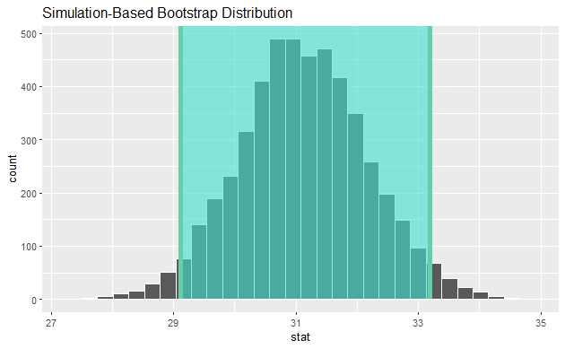

```r
infer_500 %>%
  visualise(bins = 30) +
  shade_confidence_interval(endpoints = infer_500_ci_95)
```

```r
mean_infer_500 <- infer_500 %>%
  summarise(mean = mean(stat))

mean_infer_500
```

| mean |
| --- |
| 31.11973 |

std error ~ 1/sqrt(sample size) confidence ~ std error ~ 1/sqrt(sample size)

As sample size goes up, confidence intervals get narrower, std error gets lower

- inferring a mean

# 5 CI for a proportion

The overall process is very similar

```r
sample_200 %>%
  distinct(churn)
```

| churn |
| --- |
| No |
| Yes |

We want to find out the proportion of people that did churn (churn == “Yes”)

Using our infer verbe

```r
bootstrap_resample_churn <- sample_200 %>%
  specify(response = churn, success = "Yes") %>%
  generate(reps = 5000, type = "bootstrap") %>%
  calculate(stat = "prop")

head(bootstrap_resample_churn)
```

```
Response: churn (factor)
```

| replicate | stat |
| --- | --- |
| 1 | 0.225 |
| 2 | 0.285 |
| 3 | 0.280 |
| 4 | 0.250 |
| 5 | 0.250 |
| 6 | 0.305 |

2. get our CI boundaries

```r
churn_ci_95 <- bootstrap_resample_churn %>%
  get_ci(level = 0.95, type = "percentile")

churn_ci_95
```

| lower_ci | upper_ci |
| --- | --- |
| 0.195 | 0.315 |

After that we want to visualise our CI

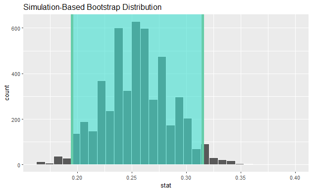

```r
bootstrap_resample_churn %>%
  visualise(bins = 30) +
  shade_ci(endpoints = churn_ci_95)
```

Finally, calculate out point estimate

```r
prop_churn_bootstrap <- bootstrap_resample_churn %>%
  summarise(mean = mean(stat))

prop_churn_bootstrap
```

| mean |
| --- |
| 0.254816 |

Our inference: we measure the proportion of customers who DO churn to be 0.254 with a 95% confidence that the true proportion is between 0.195 and 0.315.